# ST762-Asm03-LinearRgLogit-2022

#### (c) [4 marks] Fit a logistic regression model using ####log(views+1) as the regressor. Is this model

####preferred over (a)?

(slide01_P88)

```r
#  Yes, the model with log(views+1) is preferred over the model in (a) ,since log(views+1) is needed , but views is not needed.

# The reasons are: 1)H0 is: the regressors are not needed.  But p-value for log(views+1) is 0.022 < 0.05, it means there is an  evidence to reject H0 , but the evidence is not very strong. it means log(views+1) is needed for the model, but log(views+1) is not very siginificant.


# Comparing to the model in (a) where the p-value for views is 0.12 > 0.05, it is large, it means there is no evidance to reject H0, thus, views  is not significant for the model.


# Moreover,  Chisq test is  likely to support the above conclusion:   in chisq test, p-value for log(views+1) is 0.012 which is relatively small, it means log(views+1) is needed , but not very significant, log(views+1) would improve the model a little bit.


# In Chisq test, p-value for views is  0.013 which is also small, it means views is needed for the model, but not very much needed. This conclusion is opposite to the above conclusion regarding views.

# As a overall result of , full model in (c) with log(views+1) would perform a bit better than the model with views in (a).


vid.glm.lg=glm(plays~log(views+1),family=binomial,data=vid.df)


summary(vid.glm.lg)
```

```
##
## Call:
## glm(formula = plays ~ log(views + 1), family = binomial, data = vid.df)
##
## Deviance Residuals:
##     Min       1Q   Median       3Q      Max
## -1.3257  -0.7007  -0.5957  -0.2551   2.3126
##
## Coefficients:
##                Estimate Std. Error z value Pr(>|z|)
## (Intercept)     -3.5013     1.1396  -3.072  0.00212 **
## log(views + 1)   0.5016     0.2195   2.286  0.02228 *
## ---
## Signif. codes:  0 '***' 0.001 '**' 0.01 '*' 0.05 '.' 0.1 ' ' 1
##
## (Dispersion parameter for binomial family taken to be 1)
##
##     Null deviance: 55.108  on 49  degrees of freedom
## Residual deviance: 48.816  on 48  degrees of freedom
## AIC: 52.816
##
## Number of Fisher Scoring iterations: 4
```

```r
anova(vid.glm.lg,test="Chisq")
```

```
## Analysis of Deviance Table
##
## Model: binomial, link: logit
##
## Response: plays
##
## Terms added sequentially (first to last)
##
##
##                Df Deviance Resid. Df Resid. Dev Pr(>Chi)
## NULL                              49     55.108
## log(views + 1)  1   6.2918        48     48.816  0.01213 *
## ---
## Signif. codes:  0 '***' 0.001 '**' 0.01 '*' 0.05 '.' 0.1 ' ' 1
```

```r
anova(vid.glm, test="Chisq")
```

```
## Analysis of Deviance Table
##
## Model: binomial, link: logit
##
## Response: plays
##
## Terms added sequentially (first to last)
##
##
##       Df Deviance Resid. Df Resid. Dev Pr(>Chi)
## NULL                     49     55.108
## views  1   6.0647        48     49.043  0.01379 *
## ---
## Signif. codes:  0 '***' 0.001 '**' 0.01 '*' 0.05 '.' 0.1 ' ' 1
```

```r
# 1-pchisq((55.108-48.816),1)
#  # [1] 0.01212841# log(views+1)
#
# 1-pchisq(55.108-49.043,1)
#
# # [1] 0.01378868 # views
```

#### (d) [5 marks] Plot the data and the logistic ####regression curve from (d), with log(views+1) on the

####x-axis.

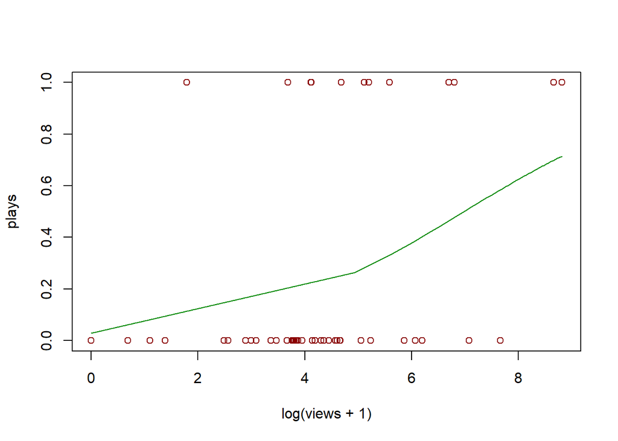

```r
# new.df=data.frame(views=vid.df$views)

new.df=data.frame(views=seq(min(vid.df$views),max(vid.df$views),len=50))

new.df$plays=predict(vid.glm.lg,newdata=new.df,type="response")

plot(plays~log(views+1),vid.df,col="red4")
lines(plays~log(views+1),new.df,col="green4")
```

### Question 3 [15 marks]

####Perform a parametric boostrap on the videos data, ####using log(views+1) as the regressor. Use the ####code given in class as a starting point, and produce ####the following outputs:

#### (a) A histogram of the estimated sampling ####distributions for β0 and β1;

```r
vid.df=read.csv("videos.csv",header = TRUE)
probit.log=glm(plays~log(views+1),family = binomial(link=probit),data = vid.df)
set.seed(314)

Nsim=1000

my.fun=function(){

  ysim=simulate(probit.log)
  mod=glm(ysim$sim_1~log(views+1),family = binomial(link=probit),data=vid.df)
  return(coef(mod))

}

out=replicate(Nsim,my.fun())
```

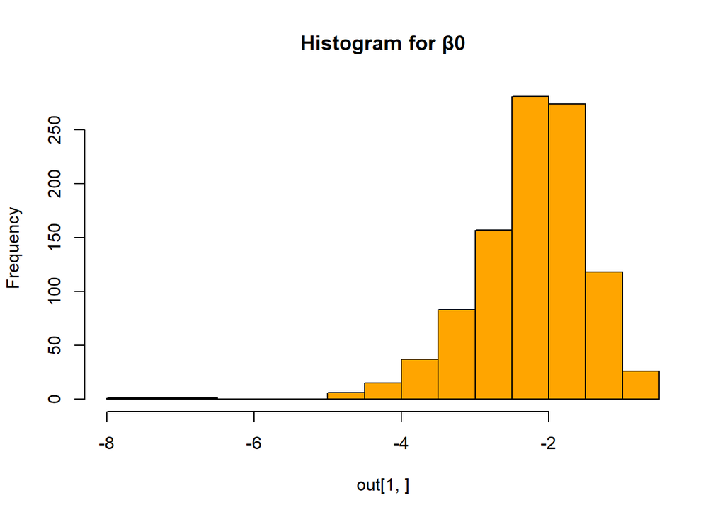

```r
hist(out[1,],main = "Histogram for β0",col="orange")
```

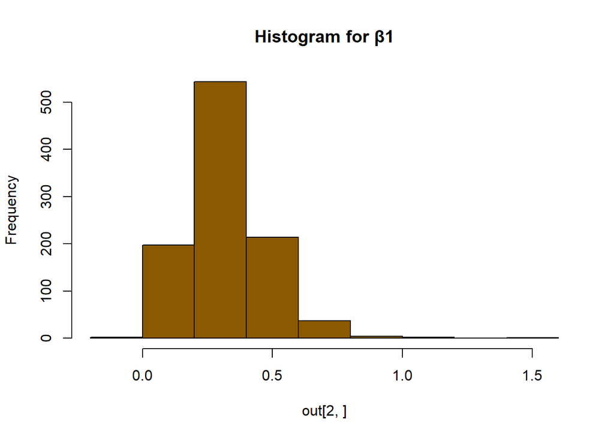

```r
hist(out[2,],main = "Histogram for β1",col="orange4")
```

#### (b) Standard errors for the coefficients;

```r
# Standard error for β0
sd(out[1,])
```

```
## [1] 0.7792146
```

```r
# Standard error for β1
sd(out[2,])
```

```
## [1] 0.1524041
```

#### (c) A 95% confidence interval for the point at which the probability of success crosses 0.5.

```r
# the probit link function is the inverse of cdf Normal distribution, for probability of success crossed 0.5 , the probit link function can be found as below

qnorm(0.50)
```

```
## [1] 0
```

```r
# 0
```

```r
p50=(0-coef(probit.log)[1])/coef(probit.log)[2]

p50.est=(0-out[1,])/out[2,]

c(2*p50-quantile(p50.est,prob=0.975) ,2*p50-quantile(p50.est,prob=0.025)  )
```

```
## (Intercept) (Intercept)
##   -1.836919    8.684917
```

```r
# (Intercept) (Intercept)
#   -1.836919    8.684917
```

```r
a=c(7,8,23,39,46,48,49,74,75,82,84,103,113,114,115,118)

b=c(19,21,33,34,61,78,80,85,86,93,98,102,107,109,116,117)


tl=c(7,8,23,39,46,48,49,74,75,82,84,103,113,114,115,118,19,21,33,34,61,78,80,85,86,93,98,102,107,109,116,117,65)


sort(tl,decreasing = FALSE)
```

```
##  [1]   7   8  19  21  23  33  34  39  46  48  49  61  65  74  75  78  80  82  84
## [20]  85  86  93  98 102 103 107 109 113 114 115 116 117 118
```

```r
a=c(48, 84, 23, 74, 46, 82, 49, 8, 39, 103, 75, 118, 7, + 115, 113, 114, 107, 33, 102, 98, 21, 85, 34, 80, 93, 78, + 19, 117, 86, 109, 116, 61, 65)

length(a)
```

```
## [1] 33
```

```r
# 33


# pass-0

r01=c(48, 84, 23, 74, 46, 82, 49, 8)
R01=sort(r01)
R01
```

```
## [1]  8 23 46 48 49 74 82 84
```

```r
# [1]  8 23 46 48 49 74 82 84

r02=c(39, 103, 75, 118, 7, 115, 113, 114)
R02=sort(r02)
R02
```

```
## [1]   7  39  75 103 113 114 115 118
```

```r
 # 7  39  75 103 113 114 115 118

r03=c(107, 33, 102, 98, 21, 85, 34, 80)
R03=sort(r03)
R03
```

```
## [1]  21  33  34  80  85  98 102 107
```

```r
# [1]  21  33  34  80  85  98 102 107
r04=c(93, 78, 19, 117, 86, 109, 116, 61)
R04=sort(r04)
R04
```

```
## [1]  19  61  78  86  93 109 116 117
```

```r
# [1]  19  61  78  86  93 109 116 117

r05=c(65)


# Pass=1, m-1 =4-1=3 way merge  , merge R01, R02, R03

r11=c(48, 84, 23, 74, 46, 82, 49, 8,39, 103, 75, 118, 7, 115, 113, 114,107, 33, 102, 98, 21, 85, 34, 80)
R11=sort(r11,decreasing = FALSE)
R11
```

```
##  [1]   7   8  21  23  33  34  39  46  48  49  74  75  80  82  84  85  98 102 103
## [20] 107 113 114 115 118
```

```r
# [1]   7   8  21  23  33  34  39  46  48  49  74  75
# [13]  80  82  84  85  98 102 103 107 113 114 115 118

r12=c(93, 78, 19, 117, 86, 109, 116, 61,65)
R12=sort(r12,decreasing = FALSE)
R12
```

```
## [1]  19  61  65  78  86  93 109 116 117
```

```r
# [1]  19  61  65  78  86  93 109 116 117

# pass-2

r21=c(48, 84, 23, 74, 46, 82, 49, 8,39, 103, 75, 118, 7, 115, 113, 114,107, 33, 102, 98, 21, 85, 34, 80,93, 78, 19, 117, 86, 109, 116, 61,65)

# length(r21)
# 33

R21=sort(r21,decreasing = FALSE)
R21
```

```
##  [1]   7   8  19  21  23  33  34  39  46  48  49  61  65  74  75  78  80  82  84
## [20]  85  86  93  98 102 103 107 109 113 114 115 116 117 118
```

```r
#  [1]   7   8  19  21  23  33  34  39  46  48  49  61
# [13]  65  74  75  78  80  82  84  85  86  93  98 102
# [25] 103 107 109 113 114 115 116 117 118

(1000^5+1000^4)/10^6
```

```
## [1] 1.001e+09
```